# 19_cubic_from_zeros_trip

## 19_cubic_from_zeros_trip

#### Question

1. A cubic polynomial, $f(x)$, is generated by randomly selecting the three parameters, $B$, $C$, and $D$, in the equation below.

   $$f(x)~=~x^3+Bx^2+Cx+D$$

   You know the graph $y=f(x)$ has one distinct real root at $x=3$. You could predict (due to the [inflection point](https://en.wikipedia.org/wiki/Inflection_point)), that the root at $x=3$ has multiplicity 3. Indeed, in this case, the multiplicity of the root is 3.

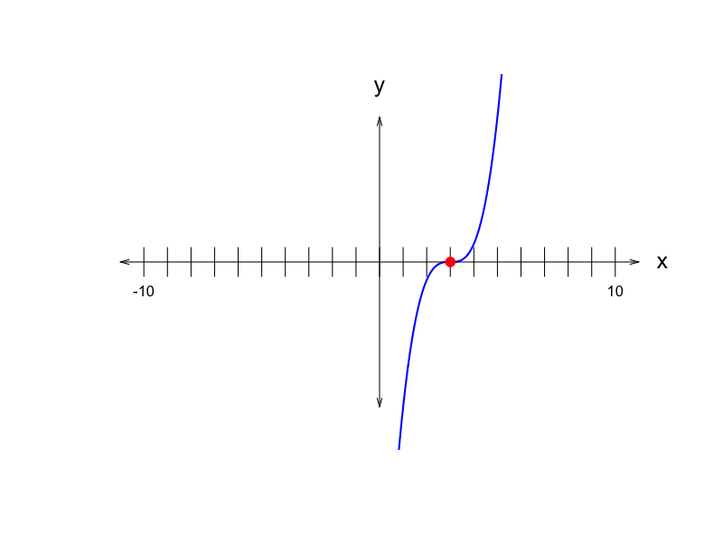

   Find $B$, $C$, and $D$.
   - $B=$
   - $C=$
   - $D=$

#### Question

2. A cubic polynomial, $f(x)$, is generated by randomly selecting the three parameters, $B$, $C$, and $D$, in the equation below.

   $$f(x)~=~x^3+Bx^2+Cx+D$$

   You know the graph $y=f(x)$ has one distinct real root at $x=-3$. You could predict (due to the [inflection point](https://en.wikipedia.org/wiki/Inflection_point)), that the root at $x=-3$ has multiplicity 3. Indeed, in this case, the multiplicity of the root is 3.

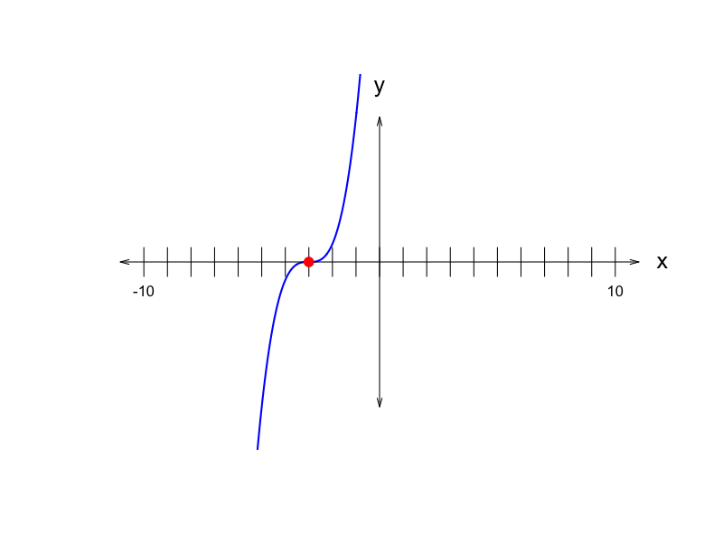

   Find $B$, $C$, and $D$.
   - $B=$
   - $C=$
   - $D=$

#### Question

3. A cubic polynomial, $f(x)$, is generated by randomly selecting the three parameters, $B$, $C$, and $D$, in the equation below.

   $$f(x)~=~x^3+Bx^2+Cx+D$$

   You know the graph $y=f(x)$ has one distinct real root at $x=1$. You could predict (due to the [inflection point](https://en.wikipedia.org/wiki/Inflection_point)), that the root at $x=1$ has multiplicity 3. Indeed, in this case, the multiplicity of the root is 3.

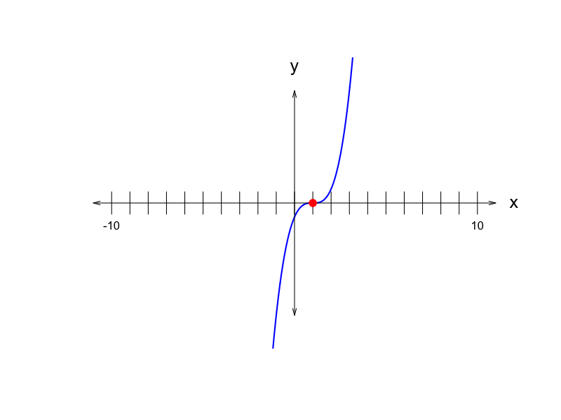

   Find $B$, $C$, and $D$.
   - $B=$
   - $C=$
   - $D=$

#### Question

4. A cubic polynomial, $f(x)$, is generated by randomly selecting the three parameters, $B$, $C$, and $D$, in the equation below.

   $$f(x)~=~x^3+Bx^2+Cx+D$$

   You know the graph $y=f(x)$ has one distinct real root at $x=-6$. You could predict (due to the [inflection point](https://en.wikipedia.org/wiki/Inflection_point)), that the root at $x=-6$ has multiplicity 3. Indeed, in this case, the multiplicity of the root is 3.

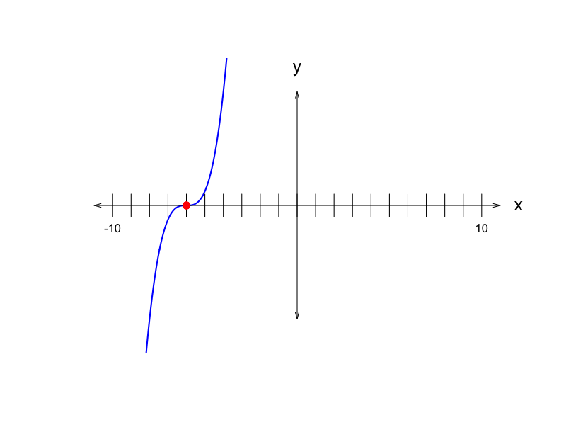

   Find $B$, $C$, and $D$.
   - $B=$
   - $C=$
   - $D=$

#### Question

5. A cubic polynomial, $f(x)$, is generated by randomly selecting the three parameters, $B$, $C$, and $D$, in the equation below.

   $$f(x)~=~x^3+Bx^2+Cx+D$$

   You know the graph $y=f(x)$ has one distinct real root at $x=-5$. You could predict (due to the [inflection point](https://en.wikipedia.org/wiki/Inflection_point)), that the root at $x=-5$ has multiplicity 3. Indeed, in this case, the multiplicity of the root is 3.

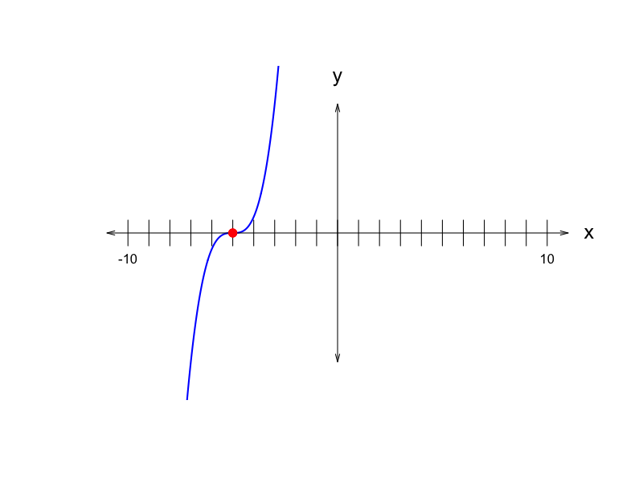

   Find $B$, $C$, and $D$.
   - $B=$
   - $C=$
   - $D=$

#### Question

6. A cubic polynomial, $f(x)$, is generated by randomly selecting the three parameters, $B$, $C$, and $D$, in the equation below.

   $$f(x)~=~x^3+Bx^2+Cx+D$$

   You know the graph $y=f(x)$ has one distinct real root at $x=1$. You could predict (due to the [inflection point](https://en.wikipedia.org/wiki/Inflection_point)), that the root at $x=1$ has multiplicity 3. Indeed, in this case, the multiplicity of the root is 3.

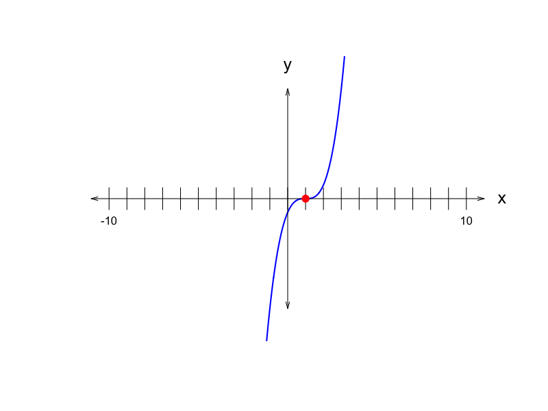

   Find $B$, $C$, and $D$.
   - $B=$
   - $C=$
   - $D=$

#### Question

7. A cubic polynomial, $f(x)$, is generated by randomly selecting the three parameters, $B$, $C$, and $D$, in the equation below.

   $$f(x)~=~x^3+Bx^2+Cx+D$$

   You know the graph $y=f(x)$ has one distinct real root at $x=5$. You could predict (due to the [inflection point](https://en.wikipedia.org/wiki/Inflection_point)), that the root at $x=5$ has multiplicity 3. Indeed, in this case, the multiplicity of the root is 3.

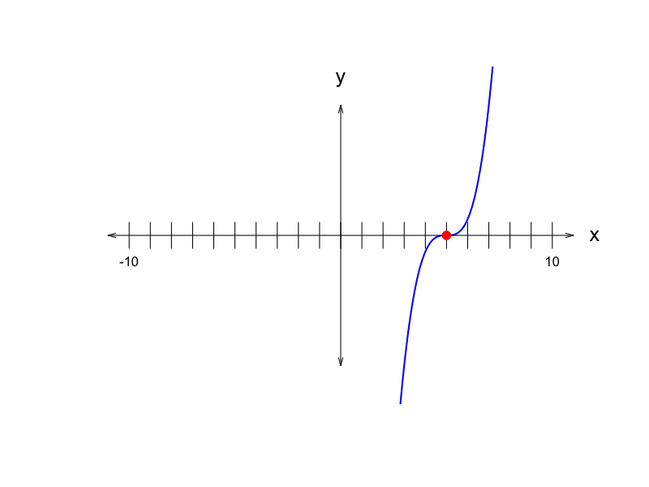

   Find $B$, $C$, and $D$.
   - $B=$
   - $C=$
   - $D=$

#### Question

8. A cubic polynomial, $f(x)$, is generated by randomly selecting the three parameters, $B$, $C$, and $D$, in the equation below.

   $$f(x)~=~x^3+Bx^2+Cx+D$$

   You know the graph $y=f(x)$ has one distinct real root at $x=-5$. You could predict (due to the [inflection point](https://en.wikipedia.org/wiki/Inflection_point)), that the root at $x=-5$ has multiplicity 3. Indeed, in this case, the multiplicity of the root is 3.

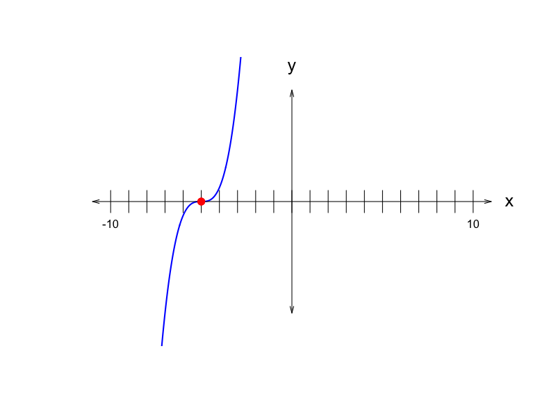

   Find $B$, $C$, and $D$.
   - $B=$
   - $C=$
   - $D=$